# HR case study

Yuting

11 January 2021

```r
#### Load required libraries
library(data.table)
```

```r
library(ggplot2)
library(ggmosaic)
library(readr)
library(readxl)
library(prediction)
HR_data <- read.csv("./HR_comma_sep.csv")
```

### Client brief

Concern: retention of high performing employees

Challengs:

1. Improvce retention of high performing colleagues
2. Predict which of its employees is most at risk of leaving

## Exploratory data analysis

### Statistical overview

```r
str(HR_data)        # shows variable types
```

```
## 'data.frame':    14999 obs. of  10 variables:
##  $ satisfaction_level   : num  0.38 0.8 0.11 0.72 0.37 0.41 0.1 0.92 0.89 0.42 ...
##  $ last_evaluation      : num  0.53 0.86 0.88 0.87 0.52 0.5 0.77 0.85 1 0.53 ...
##  $ number_project       : int  2 5 7 5 2 2 6 5 5 2 ...
##  $ average_montly_hours : int  157 262 272 223 159 153 247 259 224 142 ...
##  $ time_spend_company   : int  3 6 4 5 3 3 4 5 5 3 ...
##  $ Work_accident        : int  0 0 0 0 0 0 0 0 0 0 ...
##  $ left                 : int  1 1 1 1 1 1 1 1 1 1 ...
##  $ promotion_last_5years: int  0 0 0 0 0 0 0 0 0 0 ...
##  $ department           : Factor w/ 10 levels "accounting","hr",..: 8 8 8 8 8 8 8 8 8 8 ...
##  $ salary               : Factor w/ 3 levels "high","low","medium": 2 3 3 2 2 2 2 2 2 2 ...
```

```r
summary(HR_data)    # summary table
```

```
##  satisfaction_level last_evaluation  number_project  average_montly_hours
##  Min.   :0.0900     Min.   :0.3600   Min.   :2.000   Min.   : 96.0
##  1st Qu.:0.4400     1st Qu.:0.5600   1st Qu.:3.000   1st Qu.:156.0
##  Median :0.6400     Median :0.7200   Median :4.000   Median :200.0
##  Mean   :0.6128     Mean   :0.7161   Mean   :3.803   Mean   :201.1
##  3rd Qu.:0.8200     3rd Qu.:0.8700   3rd Qu.:5.000   3rd Qu.:245.0
##  Max.   :1.0000     Max.   :1.0000   Max.   :7.000   Max.   :310.0
##
##  time_spend_company Work_accident         left        promotion_last_5years
##  Min.   : 2.000     Min.   :0.0000   Min.   :0.0000   Min.   :0.00000
##  1st Qu.: 3.000     1st Qu.:0.0000   1st Qu.:0.0000   1st Qu.:0.00000
##  Median : 3.000     Median :0.0000   Median :0.0000   Median :0.00000
##  Mean   : 3.498     Mean   :0.1446   Mean   :0.2381   Mean   :0.02127
##  3rd Qu.: 4.000     3rd Qu.:0.0000   3rd Qu.:0.0000   3rd Qu.:0.00000
##  Max.   :10.000     Max.   :1.0000   Max.   :1.0000   Max.   :1.00000
##
##        department      salary
##  sales      :4140   high  :1237
##  technical  :2720   low   :7316
##  support    :2229   medium:6446
##  IT         :1227
##  product_mng: 902
##  marketing  : 858
##  (Other)    :2923
```

The summary table shows that

1. Turnover rate = 0.24
2. Mean satisfaction level = 0.61

```r
aggregate(HR_data[,c("satisfaction_level","last_evaluation","number_project",
     "average_montly_hours","time_spend_company","Work_accident",
     "promotion_last_5years")], by=list(Category=HR_data$left), FUN=mean)
```

| Category | satisfaction_level | last_evaluation | number_project | average_montly_hours | time_spend_company | Work_accident | promotion_last_5years |
| --- | --- | --- | --- | --- | --- | --- | --- |
| 0 | 0.6668096 | 0.7154734 | 3.786664 | 199.0602 | 3.380032 | 0.17500875 | 0.026251313 |
| 1 | 0.4400980 | 0.7181126 | 3.855503 | 207.4192 | 3.876505 | 0.04732568 | 0.005320638 |

The table shows variables difference between retention and non-retention group.

### Visualisation

#### Correlation

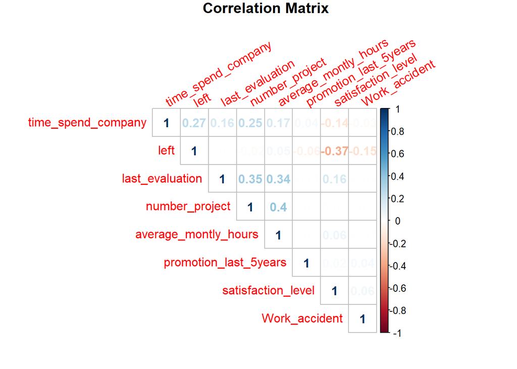

```r
library(corrplot)
correlations <- cor(HR_data[,c(1:8)], use="pairwise", method="spearman")

corrplot(correlations, tl.srt = 30,title='Correlation Matrix', mar=c(0,1,1,0),
         method="number", type="upper", order="hclust")
```

Positive correlation (>0.3):

Evaluation & number of project

Evaluation & Average monthly hours

Number of project & Average monthly hours

Negative correlation (<-0.3):

Turnover rate & Satisfaction level

Conclusion:

1. Employees with higher working hours and more projects tends to have higher evaluation.
2. Higher satisfaction leads to less probability of turnover.

### Relationship between dependent and independent variables

#### Turnover vs Satisfaction level & Evaluation rate

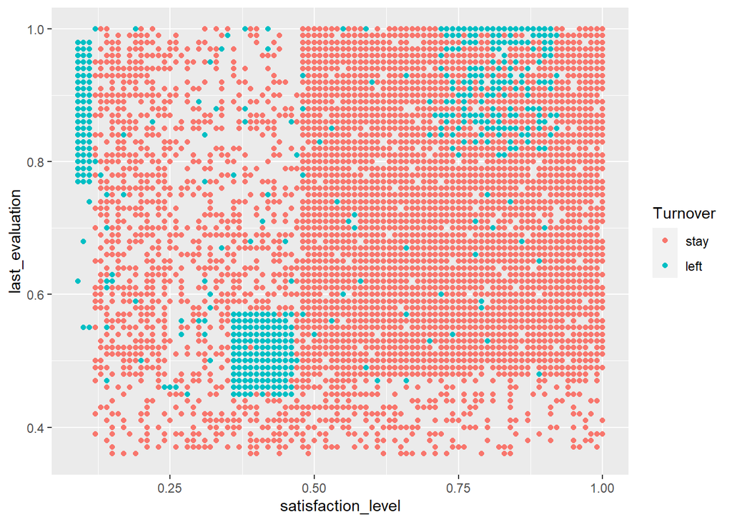

```r
qplot(satisfaction_level, last_evaluation, data=HR_data, color=factor(left)) +
  scale_colour_discrete(name="Turnover", labels=c("stay","left"))
```

There are 3 clusters for left employees.

1. Employees with high evaluation rate(>0.75) and low satisfaction level(<0.1).
2. Employees with low evaluation rate(0.45-0.6) and medium to low satisfaction level(0.3-0.5).
3. Employees with high evaluation rate(>0.8) and high satisfaction rate(0.75-0.9).

Therefore, low retention of high performing employees does exist.

### Turnover vs average_montly_hours & time_spend_company

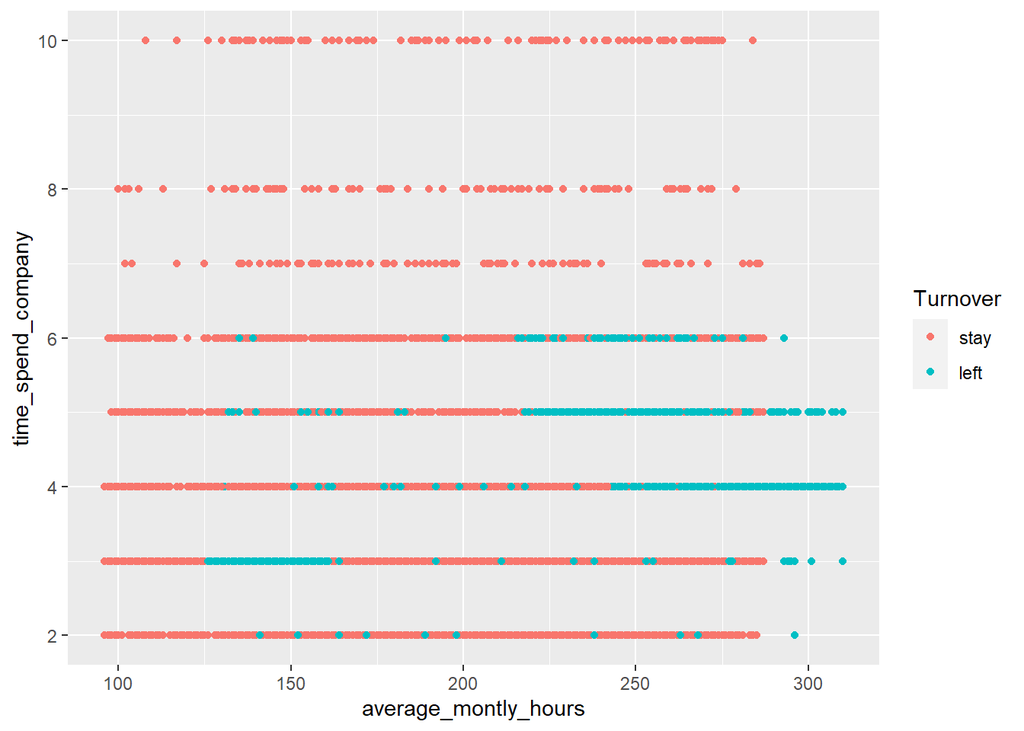

```r
qplot(average_montly_hours, time_spend_company, data=HR_data, color=factor(left)) +
  scale_colour_discrete(name="Turnover", labels=c("stay","left"))
```

There are some trends and mainly 2 clusters for employees that have left.

1. Employees that spend between 3yrs and 6yrs with company tend to leave.
2. Employees that spend 4-6 yrs with the company and have long monthly working hours (>225) tend to leave.
3. Employees that spend 3 yrs with company and have monthly working hour 125-160 hrs tend to leave.

### Number of project vs Turnover

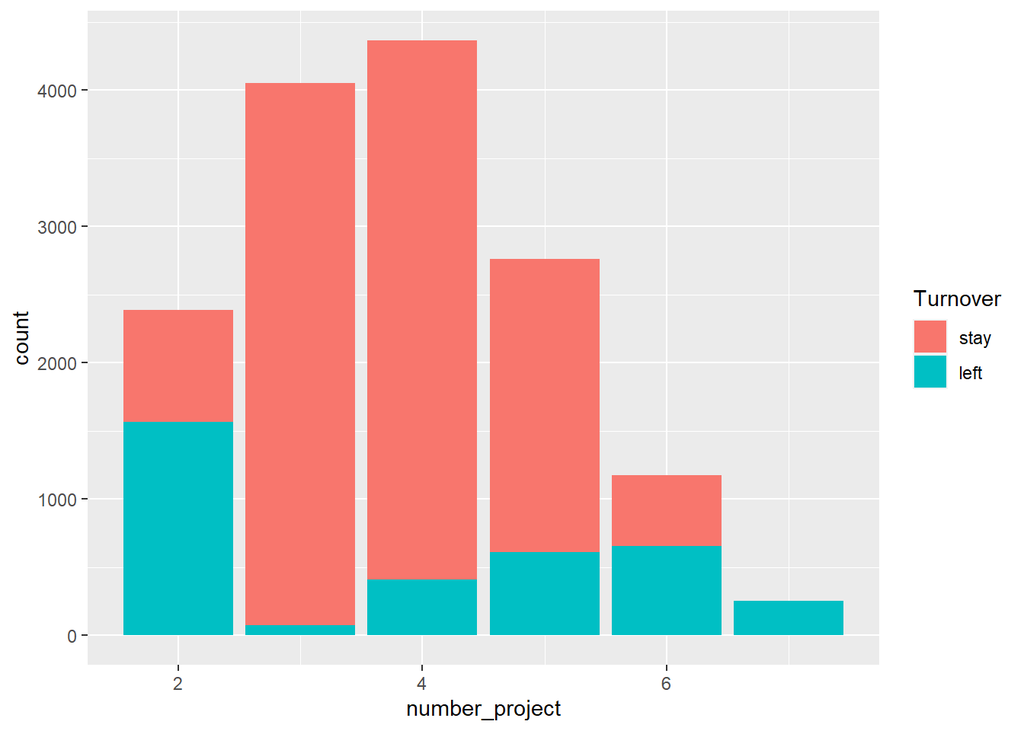

```r
ggplot(HR_data, aes(x=number_project, fill=factor(left))) + geom_bar() +
  scale_fill_discrete(name="Turnover", labels=c("stay","left"))
```

### Promotion vs Turnover

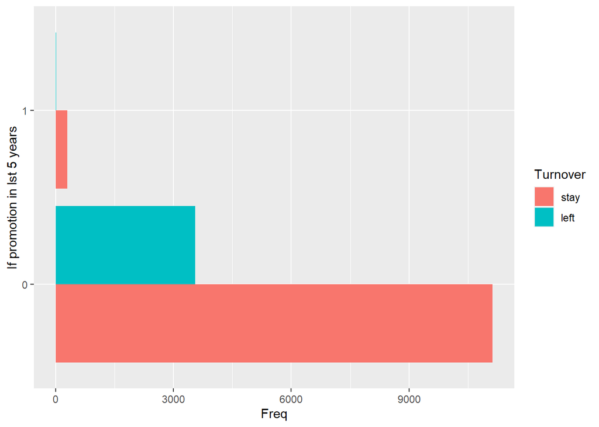

```r
vis_3<-table(HR_data$promotion_last_5years,HR_data$left)
d_vis_3<-as.data.frame(vis_3)
#print(d_vis_1)

ggplot(d_vis_3, aes(x=Var1,y=Freq,fill=Var2)) +
 geom_bar(position="dodge",stat='identity') + coord_flip() +
  labs(x="If promotion in lst 5 years", size="horsepower") +
  scale_fill_discrete(name="Turnover", labels=c("stay","left"))
```

Overall the promotion rate in the last five years was low. For people that have left, almost none received promotion.

### Department vs Turnover

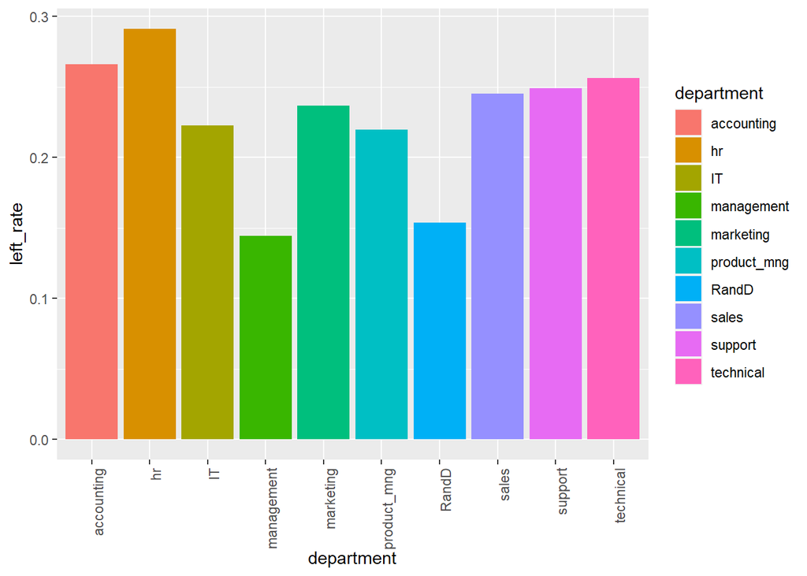

```r
vis_2<-table(HR_data$department,HR_data$left)
left_rate = vis_2[,2]/( vis_2[,1] + vis_2[,2])

x=as.data.frame(left_rate)
library(data.table)
x=setDT(x, keep.rownames = "department")[]

ggplot(x, aes(department, left_rate, fill=department)) +
  geom_col()+
          theme(axis.text.x = element_text(angle = 90, hjust = 1))
```

HR department has the highest turnover rate while management has the least.

### Salary vs Turnover

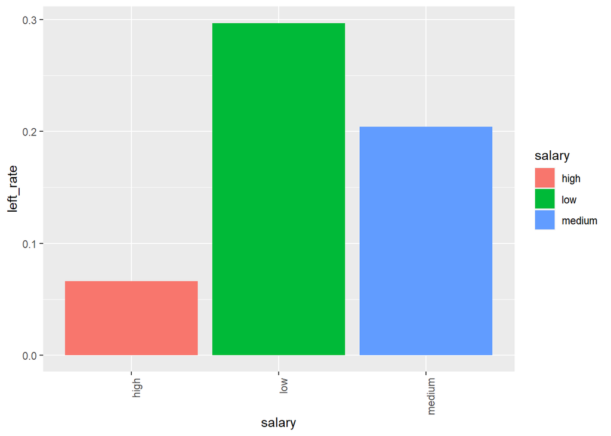

```r
vis_2<-table(HR_data$salary,HR_data$left)
left_rate = vis_2[,2]/( vis_2[,1] + vis_2[,2])

x=as.data.frame(left_rate)
library(data.table)
x=setDT(x, keep.rownames = "salary")[]

ggplot(x, aes(salary, left_rate, fill=salary)) +
  geom_col()+
          theme(axis.text.x = element_text(angle = 90, hjust = 1))
```

Compared to employees who stayed, turnover group has much higher relative frequencies for low salary employees. Not many employees with high salary left.

## Modeling

### Data splitting

```r
set.seed(1234)
train_ind=sample(nrow(HR_data),floor(0.75 * nrow(HR_data)))
# separating the data into ratio 2:1
train=HR_data[train_ind,]
test=HR_data[-train_ind,]
```

### 1. Logistic regression

Logistic regression can shows how the independent variables can affect the dependent variable(left).

```r
model_LR <- glm(left ~.,family=binomial(link='logit'),data=train)
summary(model_LR)
```

```
##
## Call:
## glm(formula = left ~ ., family = binomial(link = "logit"), data = train)
##
## Deviance Residuals:
##     Min       1Q   Median       3Q      Max
## -2.2010  -0.6593  -0.3992  -0.1318   2.9977
##
## Coefficients:
##                         Estimate Std. Error z value Pr(>|z|)
## (Intercept)           -1.3519337  0.2225588  -6.075 1.24e-09 ***
## satisfaction_level    -4.1547315  0.1137025 -36.540  < 2e-16 ***
## last_evaluation        0.7543855  0.1715963   4.396 1.10e-05 ***
## number_project        -0.3093657  0.0246392 -12.556  < 2e-16 ***
## average_montly_hours   0.0045425  0.0005951   7.633 2.29e-14 ***
## time_spend_company     0.2577213  0.0179842  14.330  < 2e-16 ***
## Work_accident         -1.4286956  0.1009891 -14.147  < 2e-16 ***
## promotion_last_5years -1.4169504  0.3102396  -4.567 4.94e-06 ***
## departmenthr           0.1499789  0.1515211   0.990  0.32226
## departmentIT          -0.2852913  0.1403973  -2.032  0.04215 *
## departmentmanagement  -0.5882847  0.1851158  -3.178  0.00148 **
## departmentmarketing   -0.0387406  0.1509575  -0.257  0.79746
## departmentproduct_mng -0.2258166  0.1504020  -1.501  0.13325
## departmentRandD       -0.7215469  0.1695029  -4.257 2.07e-05 ***
## departmentsales       -0.0905684  0.1173452  -0.772  0.44023
## departmentsupport     -0.0312066  0.1250345  -0.250  0.80291
## departmenttechnical   -0.0832895  0.1222954  -0.681  0.49584
## salarylow              1.8606740  0.1451524  12.819  < 2e-16 ***
## salarymedium           1.3269481  0.1460520   9.085  < 2e-16 ***
## ---
## Signif. codes:  0 '***' 0.001 '**' 0.01 '*' 0.05 '.' 0.1 ' ' 1
##
## (Dispersion parameter for binomial family taken to be 1)
##
##     Null deviance: 12266  on 11248  degrees of freedom
## Residual deviance:  9580  on 11230  degrees of freedom
## AIC: 9618
##
## Number of Fisher Scoring iterations: 5
```

Within the significant variables:

Negative correlation: satisfaction_level, number_project, Work_accident, promotion_last_5years, departmentRandD.

It means that the higher these variables, the less employees would leave.

Positive correlation: last_evaluation, average_montly_hours, time_spend_company, salarylow, salarymedium.

It means that the higher these variables, more likely emoployees would leave.

#### Evaluating the model

```r
p_LR <- predict(model_LR, newdata=subset(test,select=-c(left)), type="response")
p2_LR=floor(p_LR+0.5)
```

```r
library(caret)
library(e1071)
confusionMatrix(data = as.factor(p2_LR), reference = as.factor(test$left))
```

```
## Confusion Matrix and Statistics
##
##           Reference
## Prediction    0    1
##          0 2634  640
##          1  188  288
##
##                Accuracy : 0.7792
##                  95% CI : (0.7656, 0.7924)
##     No Information Rate : 0.7525
##     P-Value [Acc > NIR] : 6.956e-05
##
##                   Kappa : 0.2913
##
##  Mcnemar's Test P-Value : < 2.2e-16
##
##             Sensitivity : 0.9334
##             Specificity : 0.3103
##          Pos Pred Value : 0.8045
##          Neg Pred Value : 0.6050
##              Prevalence : 0.7525
##          Detection Rate : 0.7024
##    Detection Prevalence : 0.8731
##       Balanced Accuracy : 0.6219
##
##        'Positive' Class : 0
##
```

Because there could be some non-linear and complex relationship between variables, we also want to build decision tree model that may outperform linear regression.

### Decision tree

```r
library(rpart)
```

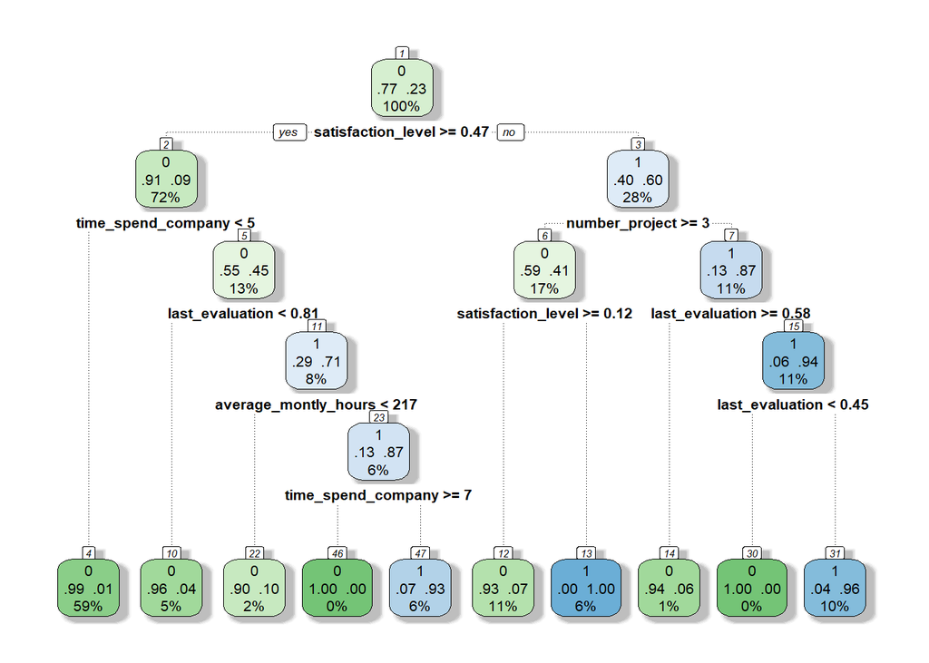

```r
library(rpart.plot)
fit_DT <- rpart(left~., data = train, method = 'class')
rpart.plot(fit_DT, extra=104, box.palette="GnBu", branch.lty=3, shadow.col="gray", nn=TRUE)
```

```r
predict_left <-predict(fit_DT, subset(test,select=-c(left)), type = 'class')
confusionMatrix(data = as.factor(predict_left), reference = as.factor(test$left))
```

```
## Confusion Matrix and Statistics
##
##           Reference
## Prediction    0    1
##          0 2783   75
##          1   39  853
##
##                Accuracy : 0.9696
##                  95% CI : (0.9636, 0.9749)
##     No Information Rate : 0.7525
##     P-Value [Acc > NIR] : < 2.2e-16
##
##                   Kappa : 0.9173
##
##  Mcnemar's Test P-Value : 0.001045
##
##             Sensitivity : 0.9862
##             Specificity : 0.9192
##          Pos Pred Value : 0.9738
##          Neg Pred Value : 0.9563
##              Prevalence : 0.7525
##          Detection Rate : 0.7421
##    Detection Prevalence : 0.7621
##       Balanced Accuracy : 0.9527
##
##        'Positive' Class : 0
##
```

It does have a higher accuracy.

## High performing employees

We define high performing employees to be the ones with evaluation rate higher than 0.72.

```r
# evaluation higher than mean/median
high_data=subset(HR_data,  last_evaluation > 0.72)
```

## Exploratory data analysis

### Statistical overview

```r
str(high_data)        # shows variable types
```

```
## 'data.frame':    7395 obs. of  10 variables:
##  $ satisfaction_level   : num  0.8 0.11 0.72 0.1 0.92 0.89 0.11 0.84 0.78 0.76 ...
##  $ last_evaluation      : num  0.86 0.88 0.87 0.77 0.85 1 0.81 0.92 0.99 0.89 ...
##  $ number_project       : int  5 7 5 6 5 5 6 4 4 5 ...
##  $ average_montly_hours : int  262 272 223 247 259 224 305 234 255 262 ...
##  $ time_spend_company   : int  6 4 5 4 5 5 4 5 6 5 ...
##  $ Work_accident        : int  0 0 0 0 0 0 0 0 0 0 ...
##  $ left                 : int  1 1 1 1 1 1 1 1 1 1 ...
##  $ promotion_last_5years: int  0 0 0 0 0 0 0 0 0 0 ...
##  $ department           : Factor w/ 10 levels "accounting","hr",..: 8 8 8 8 8 8 8 8 8 8 ...
##  $ salary               : Factor w/ 3 levels "high","low","medium": 3 3 2 2 2 2 2 2 2 2 ...
```

```r
summary(high_data)    # summary table
```

```
##  satisfaction_level last_evaluation  number_project  average_montly_hours
##  Min.   :0.0900     Min.   :0.7300   Min.   :2.000   Min.   : 96.0
##  1st Qu.:0.5000     1st Qu.:0.8000   1st Qu.:3.000   1st Qu.:177.0
##  Median :0.7000     Median :0.8700   Median :4.000   Median :225.0
##  Mean   :0.6245     Mean   :0.8685   Mean   :4.208   Mean   :216.9
##  3rd Qu.:0.8350     3rd Qu.:0.9400   3rd Qu.:5.000   3rd Qu.:256.0
##  Max.   :1.0000     Max.   :1.0000   Max.   :7.000   Max.   :310.0
##
##  time_spend_company Work_accident         left        promotion_last_5years
##  Min.   : 2.000     Min.   :0.0000   Min.   :0.0000   Min.   :0.00000
##  1st Qu.: 3.000     1st Qu.:0.0000   1st Qu.:0.0000   1st Qu.:0.00000
##  Median : 3.000     Median :0.0000   Median :0.0000   Median :0.00000
##  Mean   : 3.694     Mean   :0.1416   Mean   :0.2556   Mean   :0.02042
##  3rd Qu.: 4.000     3rd Qu.:0.0000   3rd Qu.:1.0000   3rd Qu.:0.00000
##  Max.   :10.000     Max.   :1.0000   Max.   :1.0000   Max.   :1.00000
##
##        department      salary
##  sales      :1954   high  : 573
##  technical  :1378   low   :3627
##  support    :1154   medium:3195
##  IT         : 601
##  product_mng: 448
##  marketing  : 407
##  (Other)    :1453
```

The summary table shows that

1. Turnover rate = 0.26
2. Mean satisfaction level = 0.63

```r
aggregate(high_data[,c("satisfaction_level","last_evaluation","number_project",
     "average_montly_hours","time_spend_company","Work_accident",
     "promotion_last_5years")], by=list(Category=high_data$left), FUN=mean)
```

| Category | satisfaction_level | last_evaluation | number_project | average_montly_hours | time_spend_company | Work_accident | promotion_last_5years |
| --- | --- | --- | --- | --- | --- | --- | --- |
| 0 | 0.6800436 | 0.8590500 | 3.829791 | 203.1213 | 3.392552 | 0.17384196 | 0.026702997 |
| 1 | 0.4625820 | 0.8960423 | 5.308995 | 256.9460 | 4.573545 | 0.04761905 | 0.002116402 |

The table shows variables difference between retention and non-retention group.

### Visualisation

#### Correlation

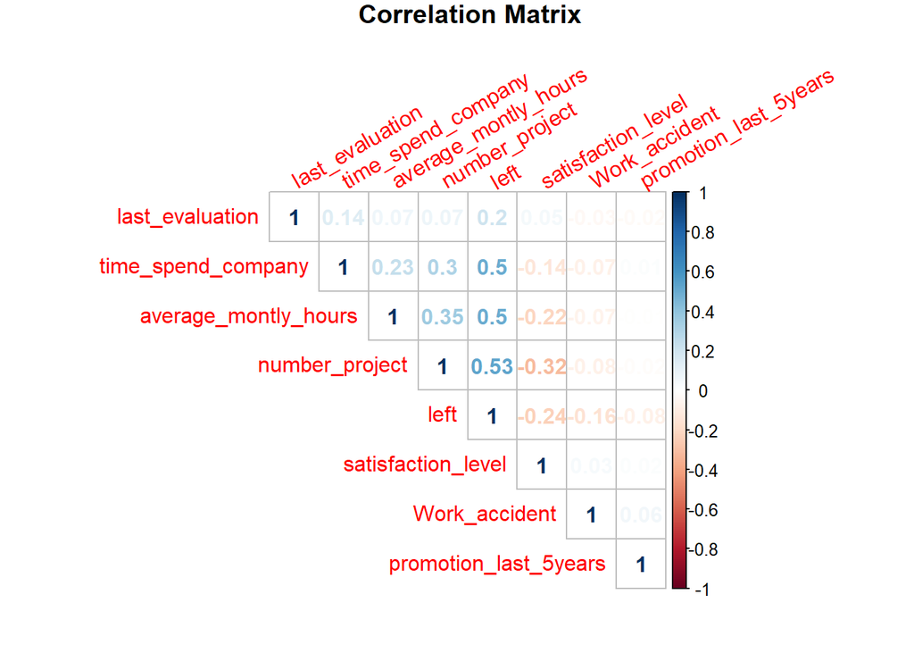

```r
library(corrplot)
correlations <- cor(high_data[,c(1:8)], use="pairwise", method="spearman")

corrplot(correlations, tl.srt = 30,title='Correlation Matrix', mar=c(0,1,1,0),
         method="number", type="upper", order="hclust")
```

Positive correlation (>0.3):

Left & number of project

Left & Average monthly hours

Left & Years with company

Number of project & Average monthly hours

Negative correlation (<-0.3):

Number of project & Satisfaction level

Conclusion:

1. High number of projects, working hours and years with company could leads to turnover.
2. Higher project count leads to lower satisfaction rate.

### Relationship between dependent and independent variables

#### Turnover vs Satisfaction level & Evaluation rate

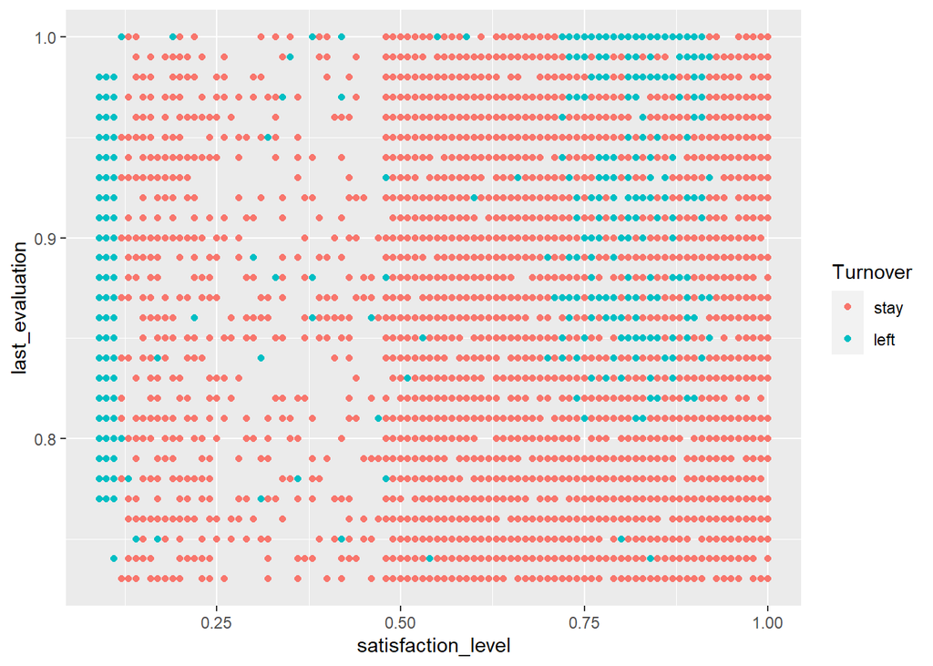

```r
qplot(satisfaction_level, last_evaluation, data=high_data, color=factor(left)) +
  scale_colour_discrete(name="Turnover", labels=c("stay","left"))
```

### Turnover vs average_montly_hours & time_spend_company

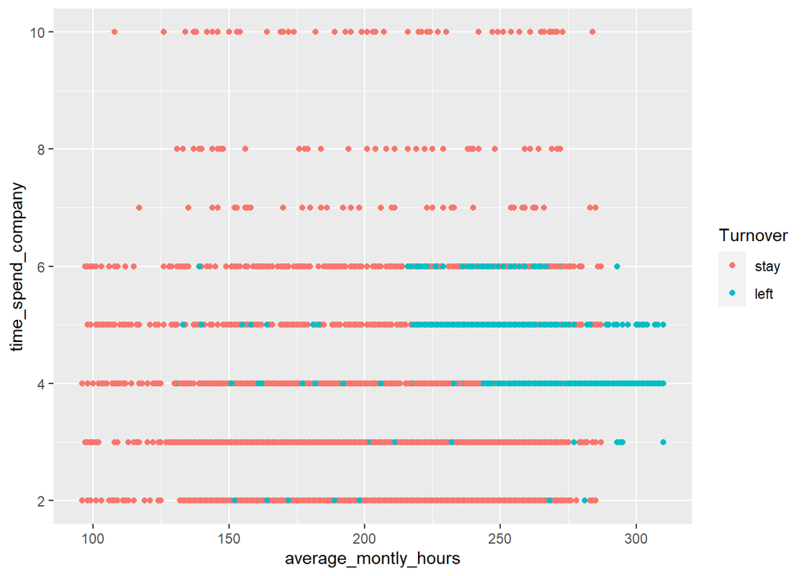

```r
qplot(average_montly_hours, time_spend_company, data=high_data, color=factor(left)) +
  scale_colour_discrete(name="Turnover", labels=c("stay","left"))
```

There are some trends and mainly 2 clusters for employees that have left.

### Number of project vs Turnover

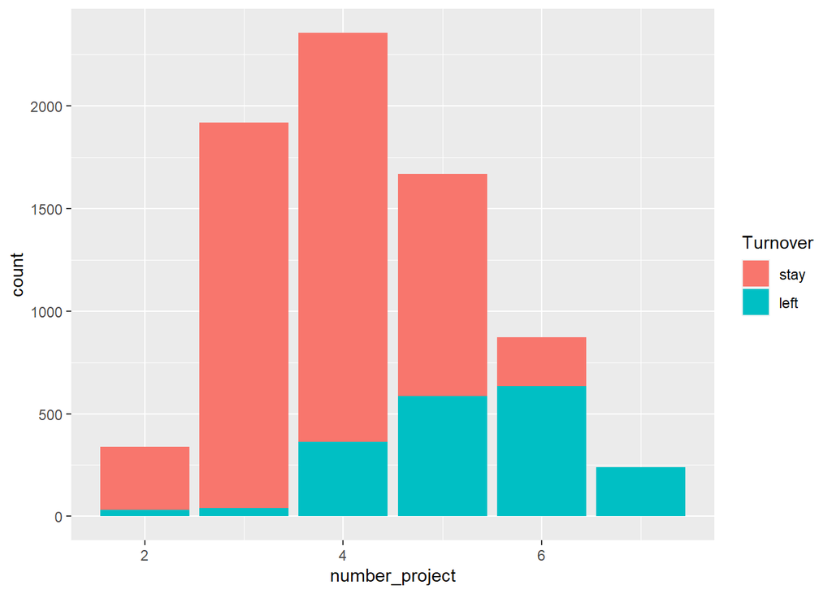

```r
ggplot(high_data, aes(x=number_project, fill=factor(left))) + geom_bar() +
  scale_fill_discrete(name="Turnover", labels=c("stay","left"))
```

1. All employees that worked on seven projects have left.
2. There is an increasing trend of leaving as number of project builds up.

### Promotion vs Turnover

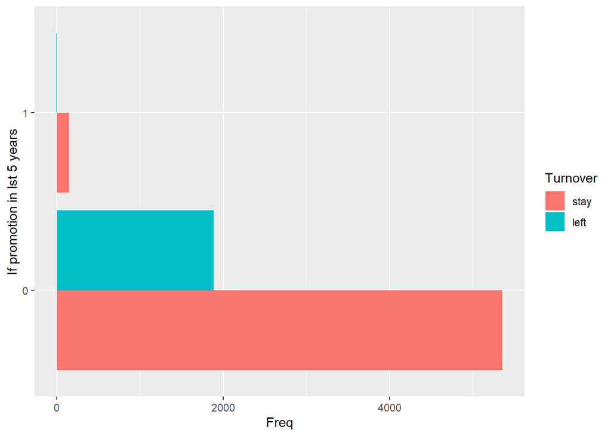

```r
vis_3<-table(high_data$promotion_last_5years,high_data$left)
d_vis_3<-as.data.frame(vis_3)
#print(d_vis_1)

ggplot(d_vis_3, aes(x=Var1,y=Freq,fill=Var2)) +
 geom_bar(position="dodge",stat='identity') + coord_flip() +
  labs(x="If promotion in lst 5 years", size="horsepower") +
  scale_fill_discrete(name="Turnover", labels=c("stay","left"))
```

Overall the promotion rate in the last five years was low. For people that have left, almost none received promotion.

### Department vs Turnover

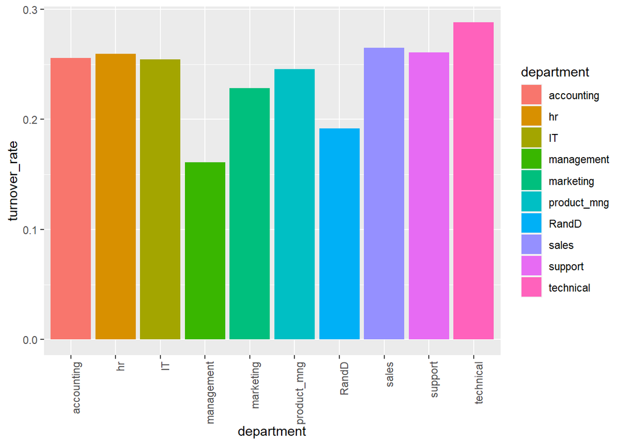

```r
vis_2<-table(high_data$department,high_data$left)
turnover_rate = vis_2[,2]/( vis_2[,1] + vis_2[,2])

x=as.data.frame(turnover_rate)
library(data.table)
x=setDT(x, keep.rownames = "department")[]

ggplot(x, aes(department, turnover_rate, fill=department)) +
  geom_col()+
          theme(axis.text.x = element_text(angle = 90, hjust = 1))
```

Technical department has the highest turnover rate while management has the least.

### Salary vs Turnover

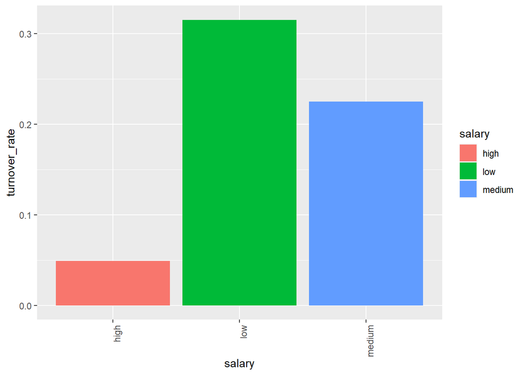

```r
vis_2<-table(high_data$salary,high_data$left)
turnover_rate = vis_2[,2]/( vis_2[,1] + vis_2[,2])

x=as.data.frame(turnover_rate)
library(data.table)
x=setDT(x, keep.rownames = "salary")[]

ggplot(x, aes(salary, turnover_rate, fill=salary)) +
  geom_col()+
          theme(axis.text.x = element_text(angle = 90, hjust = 1))
```

Compared to employees who stayed, turnover group has much higher relative frequencies for low salary employees. Not many employees with high salary left.

## Modeling

### Data splitting

```r
set.seed(1234)
train_ind=sample(nrow(high_data),floor(0.75 * nrow(high_data)))
# separating the data into ratio 2:1
train=high_data[train_ind,]
test=high_data[-train_ind,]
```

### 1. Logistic regression

Logistic regression can shows how the independent variables can affect the dependent variable(left).

```r
model_LR <- glm(left ~.,family=binomial(link='logit'),data=train)
summary(model_LR)
```

```
##
## Call:
## glm(formula = left ~ ., family = binomial(link = "logit"), data = train)
##
## Deviance Residuals:
##     Min       1Q   Median       3Q      Max
## -2.8741  -0.3485  -0.1327   0.1409   3.8066
##
## Coefficients:
##                         Estimate Std. Error z value Pr(>|z|)
## (Intercept)           -25.458861   0.937776 -27.148  < 2e-16 ***
## satisfaction_level     -0.251110   0.195561  -1.284   0.1991
## last_evaluation         8.775347   0.686488  12.783  < 2e-16 ***
## number_project          1.176369   0.057220  20.559  < 2e-16 ***
## average_montly_hours    0.029810   0.001454  20.503  < 2e-16 ***
## time_spend_company      0.569948   0.031286  18.217  < 2e-16 ***
## Work_accident          -1.272269   0.178702  -7.120 1.08e-12 ***
## promotion_last_5years  -2.703636   0.656954  -4.115 3.86e-05 ***
## departmenthr            0.705652   0.296739   2.378   0.0174 *
## departmentIT            0.165389   0.272135   0.608   0.5434
## departmentmanagement   -0.248663   0.331770  -0.750   0.4536
## departmentmarketing    -0.066107   0.301896  -0.219   0.8267
## departmentproduct_mng   0.086237   0.289795   0.298   0.7660
## departmentRandD         0.103793   0.299686   0.346   0.7291
## departmentsales         0.223482   0.229285   0.975   0.3297
## departmentsupport       0.488543   0.241984   2.019   0.0435 *
## departmenttechnical     0.413014   0.235356   1.755   0.0793 .
## salarylow               2.419432   0.287513   8.415  < 2e-16 ***
## salarymedium            1.906084   0.288295   6.612 3.80e-11 ***
## ---
## Signif. codes:  0 '***' 0.001 '**' 0.01 '*' 0.05 '.' 0.1 ' ' 1
##
## (Dispersion parameter for binomial family taken to be 1)
##
##     Null deviance: 6286.4  on 5545  degrees of freedom
## Residual deviance: 2846.0  on 5527  degrees of freedom
## AIC: 2884
##
## Number of Fisher Scoring iterations: 6
```

Within the significant variables:

Negative correlation: Work_accident, promotion_last_5years

It means that the higher these variables, the less employees would leave.

Positive correlation: last_evaluation, number_project, average_montly_hours, time_spend_company, salarylow, salarymedium.

It means that the higher these variables, more likely emoployees would leave.

#### Evaluating the model

```r
p_LR <- predict(model_LR, newdata=subset(test,select=-c(left)), type="response")
p2_LR=floor(p_LR+0.5)
```

```r
library(caret)
library(e1071)
confusionMatrix(data = as.factor(p2_LR), reference = as.factor(test$left))
```

```
## Confusion Matrix and Statistics
##
##           Reference
## Prediction    0    1
##          0 1288  104
##          1   80  377
##
##                Accuracy : 0.9005
##                  95% CI : (0.8859, 0.9138)
##     No Information Rate : 0.7399
##     P-Value [Acc > NIR] : < 2e-16
##
##                   Kappa : 0.7372
##
##  Mcnemar's Test P-Value : 0.08996
##
##             Sensitivity : 0.9415
##             Specificity : 0.7838
##          Pos Pred Value : 0.9253
##          Neg Pred Value : 0.8249
##              Prevalence : 0.7399
##          Detection Rate : 0.6966
##    Detection Prevalence : 0.7528
##       Balanced Accuracy : 0.8627
##
##        'Positive' Class : 0
##
```

Because there could be some non-linear and complex relationship between variables, we also want to build decision tree model that may outperform linear regression.

### Decision tree

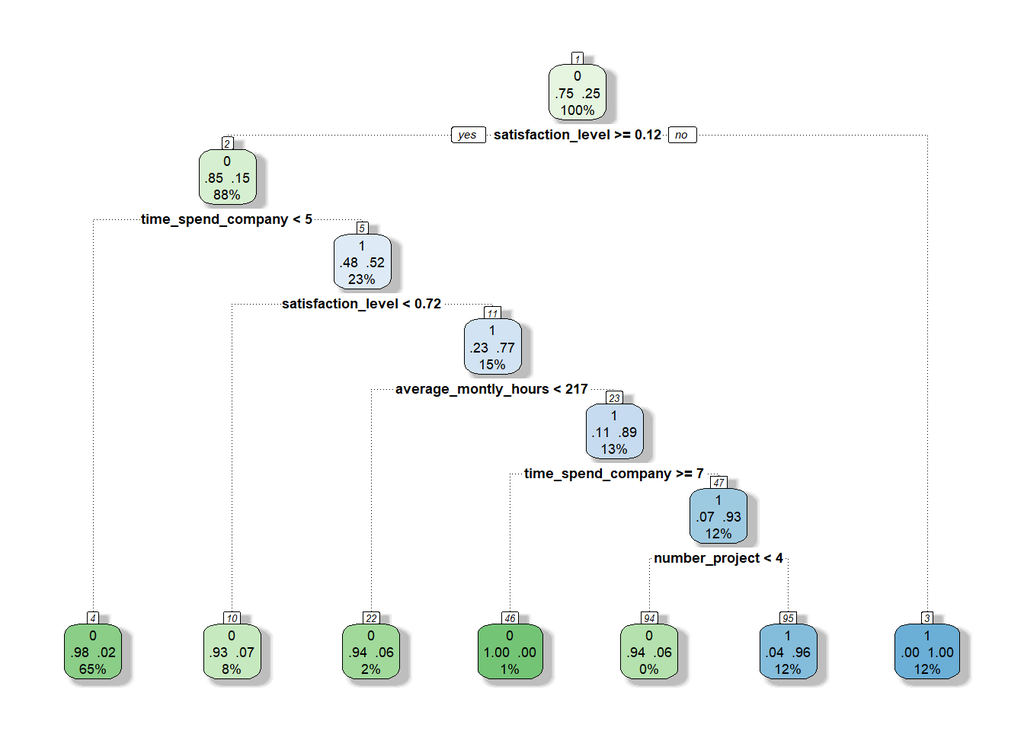

```r
library(rpart)
library(rpart.plot)
fit_DT <- rpart(left~., data = train, method = 'class')
rpart.plot(fit_DT, extra=104, box.palette="GnBu", branch.lty=3, shadow.col="gray", nn=TRUE)
```

```r
predict_left <-predict(fit_DT, subset(test,select=-c(left)), type = 'class')
confusionMatrix(data = as.factor(predict_left), reference = as.factor(test$left))
```

```
## Confusion Matrix and Statistics
##
##           Reference
## Prediction    0    1
##          0 1358   36
##          1   10  445
##
##                Accuracy : 0.9751
##                  95% CI : (0.967, 0.9817)
##     No Information Rate : 0.7399
##     P-Value [Acc > NIR] : < 2.2e-16
##
##                   Kappa : 0.9342
##
##  Mcnemar's Test P-Value : 0.0002278
##
##             Sensitivity : 0.9927
##             Specificity : 0.9252
##          Pos Pred Value : 0.9742
##          Neg Pred Value : 0.9780
##              Prevalence : 0.7399
##          Detection Rate : 0.7345
##    Detection Prevalence : 0.7539
##       Balanced Accuracy : 0.9589
##
##        'Positive' Class : 0
##
```

```r
library(randomForest)
rf_classifier = randomForest(factor(left) ~ ., data=train, ntree=100, mtry=2, importance=TRUE)                                                            #
rf_classifier
```

```
##
## Call:
##  randomForest(formula = factor(left) ~ ., data = train, ntree = 100,      mtry = 2, importance = TRUE)
##                Type of random forest: classification
##                      Number of trees: 100
## No. of variables tried at each split: 2
##
##         OOB estimate of  error rate: 1.57%
## Confusion matrix:
##      0    1 class.error
## 0 4123   14 0.003384095
## 1   73 1336 0.051809794
```

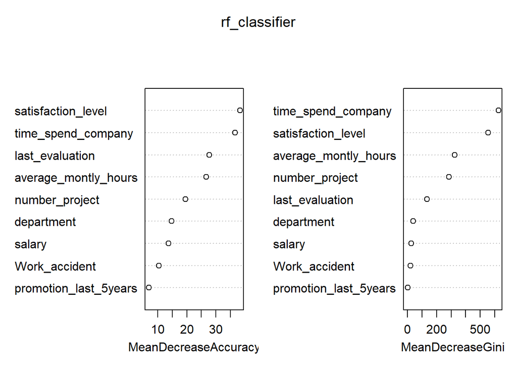

```r
varImpPlot(rf_classifier)
```

```r
prediction_for_table <- predict(rf_classifier,subset(test,select=-c(left)))
table_rf=table(observed=test$left,predicted=prediction_for_table)
```

```r
accuracy_Test <- sum(diag(table_rf)) / sum(table_rf)
print(paste('Accuracy for test', accuracy_Test))
```

```
## [1] "Accuracy for test 0.987560843699297"
```